**Probability**

# t.ly/e9ZX

```python
# IMPORT LIBRARIES
import numpy as np
import pandas as pd
import matplotlib.pyplot as plt
import seaborn as sns

# get the output for all commands
from IPython.core.interactiveshell import InteractiveShell
InteractiveShell.ast_node_interactivity = 'all'

# Ignore warnings
import warnings
warnings.filterwarnings('ignore')
```

```python
loan_df = pd.read_csv(r'C:\Data\Loan Prediction\Loan_data.csv')
```

```python
loan_df.shape
```

```
(614, 13)
```

```python
loan_df.head()
```

|  | Loan_ID | Gender | Married | Dependents | Education | Self_Employed | ApplicantIncome | CoapplicantIncome | LoanAmount | Loan_Amount_Term | Credit_History | Property_Area | Loan_Status |
| --- | --- | --- | --- | --- | --- | --- | --- | --- | --- | --- | --- | --- | --- |
| 0 | LP001002 | Male | No | 0 | Graduate | No | 5849 | 0.0 | NaN | 360.0 | 1.0 | Urban | Y |
| 1 | LP001003 | Male | Yes | 1 | Graduate | No | 4583 | 1508.0 | 128.0 | 360.0 | 1.0 | Rural | N |
| 2 | LP001005 | Male | Yes | 0 | Graduate | Yes | 3000 | 0.0 | 66.0 | 360.0 | 1.0 | Urban | Y |
| 3 | LP001006 | Male | Yes | 0 | Not Graduate | No | 2583 | 2358.0 | 120.0 | 360.0 | 1.0 | Urban | Y |
| 4 | LP001008 | Male | No | 0 | Graduate | No | 6000 | 0.0 | 141.0 | 360.0 | 1.0 | Urban | Y |

```python
loan_df.isna().sum()
```

```
Loan_ID               0
Gender               13
Married               3
Dependents           15
Education             0
Self_Employed        32
ApplicantIncome       0
CoapplicantIncome     0
LoanAmount           22
Loan_Amount_Term     14
Credit_History       50
Property_Area         0
Loan_Status           0
dtype: int64
```

### Contingency table

```python
contingency_tbl = pd.crosstab(index=loan_df.Loan_Status, columns=loan_df.Dependents, margins=True,
                             margins_name='Total')
```

```python
contingency_tbl
```

| Dependents Loan_Status | 0 | 1 | 2 | 3+ | Total |
| --- | --- | --- | --- | --- | --- |
| N | 107 | 36 | 25 | 18 | 186 |
| Y | 238 | 66 | 76 | 33 | 413 |
| Total | 345 | 102 | 101 | 51 | 599 |

### Convert into Probabilities

```python
ct_prob = contingency_tbl/599
```

```python
ct_prob
```

| Dependents Loan_Status | 0 | 1 | 2 | 3+ | Total |
| --- | --- | --- | --- | --- | --- |
| N | 0.178631 | 0.060100 | 0.041736 | 0.030050 | 0.310518 |
| Y | 0.397329 | 0.110184 | 0.126878 | 0.055092 | 0.689482 |
| Total | 0.575960 | 0.170284 | 0.168614 | 0.085142 | 1.000000 |

### Marginal probabilities - P(N), P(Y), P(0), P(1), P(2), P(3+)

### Joint probabilities - P(0 ∩ N), P(1 ∩ N),....P(0 ∩ Y), P(1 ∩ Y)....

#### Union Probablity

$P(A \cup B) = P(A) + P(B) - P(A\cap B)$

$P(A \cup B) = marginal prob + maginal prob - joint prob $

##### Compute the union probability

**`P(0 ∪ Y) = P(0) + P(Y) - P(0 ∩ Y)`**

```python
contingency_tbl.index
```

```
Index(['N', 'Y', 'Total'], dtype='object', name='Loan_Status')
```

```python
contingency_tbl.columns
```

```
Index(['0', '1', '2', '3+', 'Total'], dtype='object', name='Dependents')
```

```python
contingency_tbl.iloc[0,4]
```

```
186
```

```python
contingency_tbl.loc['N', 'Total']
```

```
186
```

```python
ct_prob.loc['Total', '0'] + ct_prob.loc['Y', 'Total'] - ct_prob.loc['Y', '0']
```

```
0.8681135225375627
```

### $ P(A \mid B) = \frac{P(A\cap B)}{P(B)} $

#### Compute the below Cond. Proba -

### $ P(Y | 0) = \frac{P(Y \; \cap \; 0)}{P(0)}$

### $ P(2 | Y) = \frac{P(Y \; \cap \; 2)}{P(Y)}$

For equation in Jupyter Notebook:

https://latexeditor.lagrida.com/

```python
# P(Y|0)

ct_prob.loc['Y', '0']/ct_prob.loc['Total', '0']
```

```
0.6898550724637681
```

```python
# P(2|Y)

ct_prob.loc['Y', '2']/ct_prob.loc['Y', 'Total']
```

```
0.1840193704600484
```

## Probability tree

```python
# Loan status vs Education

contingency_tbl = pd.crosstab(index = loan_df.Loan_Status, columns=loan_df.Education, margins=True, margins_name= 'Total')
```

```python
contingency_tbl
```

| Education Loan_Status | Graduate | Not Graduate | Total |
| --- | --- | --- | --- |
| N | 140 | 52 | 192 |
| Y | 340 | 82 | 422 |
| Total | 480 | 134 | 614 |

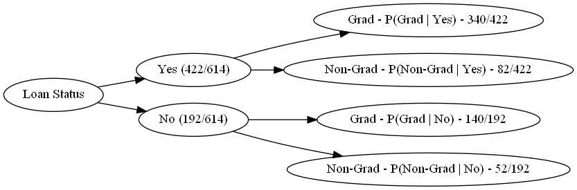

# What Are Random Variables?

A **random variable**, typically denoted as **X**, is a variable whose possible values are outcomes of a random process.

There are two types of random variables: **discrete and continuous.**

### 1. Discrete Random Variables

A discrete random variable is a variable which can take on only a countable number of distinct values like 0, 1, 2, 3, 4, 5…100, 1 million, etc. Some examples of discrete random variables include:

- The number of times a coin lands on tails after being flipped 20 times.
- The number of times a dice lands on the number 4 after being rolled 100 times.
- The number of defective widgets in a box of 50 widgets.

A **probability distribution** for a discrete random variable tells us the probability that the random variable takes on certain values.

For example, suppose we roll a fair die one time. If we let X denote the probability that the die lands on a certain number, then the probability distribution can be written as:

- P(X=1): 1/6
- P(X=2): 1/6
- P(X=3): 1/6
- P(X=4): 1/6
- P(X=5): 1/6
- P(X=6): 1/6

> Note: For a probability distribution to be valid, it must satisfy the following two criteria:  
> 1. The probability for each outcome must be between 0 and 1.  
> 2. The sum of all of the probabilities must add up to 1.

We can use a histogram to visualize the probability distribution:

```python
import numpy as np
import pandas as pd
import matplotlib.pyplot as plt
import seaborn as sns
```

```python
outcomes = np.arange(1,7)  # sample space {1,2,3,4,5,6}
proba = np.repeat(1/6,6)
```

```python
print(outcomes, proba)
```

```
[1 2 3 4 5 6] [0.16666667 0.16666667 0.16666667 0.16666667 0.16666667 0.16666667]
```

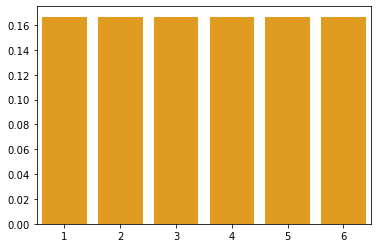

```python
sns.barplot(x = outcomes, y = proba, color='orange');
```

A **cumulative probability distribution** for a discrete random variable tells us the probability that the variable takes on a value equal to or less than some value.

For example, the cumulative probability distribution for a die roll would look like:

- P(X≤1): 1/6
- P(X≤2): 2/6
- P(X≤3): 3/6
- P(X≤4): 4/6
- P(X≤5): 5/6
- P(X≤6): 6/6

The probability that the die lands on a one or less $ P(X \leq 1) $ is simply 1/6, since it can’t land on a number less than one.

The probability that it lands on a two or less $ P(X \leq 2) $ is $ P(X=1) + P(X=2) = 1/6 + 1/6 = 2/6 $.

Similarly, the probability that it lands on a three or less is $ P(X \leq 3) = P(X=1) + P(X=2) + P(X=3) = 1/6 + 1/6 + 1/6 = 3/6 $, and so on.

We can also use a histogram to visualize the cumulative probability distribution:

```python
outcomes = np.arange(1,7)  # sample space {1,2,3,4,5,6}
proba = np.cumsum(np.repeat(1/6,6))

print(outcomes, proba)
```

```
[1 2 3 4 5 6] [0.16666667 0.33333333 0.5        0.66666667 0.83333333 1.        ]
```

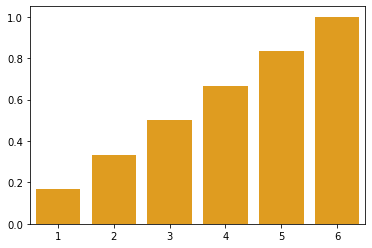

```python
sns.barplot(x = outcomes, y = proba, color='orange');
```

Here, each bar represents the probability of getting that number and previous numbers.

$ P(X \leq 2) = P(X=1) + P(X=2) = 1/6 + 1/6 = 2/6 $

$ P(X \leq 2) = 1-P( X > 2) = 1 - [P(X = 3) + P(X = 4) + .. + P(X = 6)]$

$ P(X > 2) = 1-P(X \leq 2) $

## Probability Distribution Table

A **probability distribution table** is a table that displays the probability that a random variable takes on certain values.

For example, the following probability distribution table tells us the probability that a certain soccer team scores a certain number of goals in a given game:

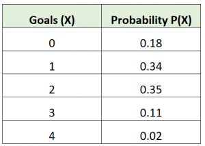

The left-hand column shows the number of goals and the right-hand column tells us the probability that the team will score this number of goals.

For example:

The probability that the team scores exactly 0 goals is 0.18. The probability that the team scores exactly 1 goal is 0.34. The probability that the team scores exactly 2 goals is 0.35.

#### Visualize a Probability Distribution Table

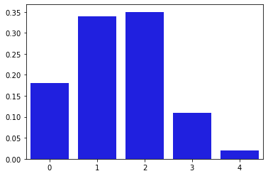

```python
goals = np.arange(5)
proba = [0.18, 0.34, 0.35, 0.11, 0.02]

sns.barplot(x = goals, y=proba, color='blue');
```

## Mean of a Probability Distribution

To find the mean (sometimes called the **“expected value”**) of any probability distribution, we can use the following formula:

Mean (Or "Expected Value - **EV**") of a Probability Distribution:

### EV = μ = Σ(x * p(x))

where:

- x: Data value
- P(x): Probability of value

The mean number of goals for the soccer team would be calculated as:

### `μ = 0*0.18 + 1*0.34 + 2*0.35 + 3*0.11 + 4*0.02 = 1.45 goals.`

## Standard Deviation of a Probability Distribution

To find the standard deviation of a probability distribution, we can use the following formula:

### $ \sigma = \sqrt{\sum{(X_i - \mu)^2} * P(X_i)} $

where:

- xi: The ith value
- μ: The mean of the distribution (EV calculated above)
- P(xi): The probability of the ith value

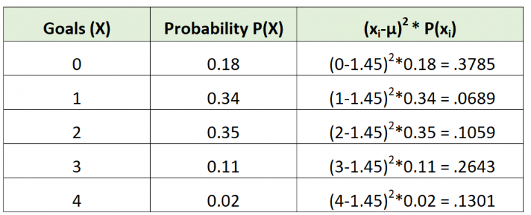

Standard deviation = $ \sqrt{(.3785 + .0689 + .1059 + .2643 + .1301)} = 0.9734 $

## Expected Value vs. Mean: What’s the Difference?

In general, we use the following terms in different situations:

- **Expected value** is used when we want to calculate the mean of a probability distribution. This represents the average value we expect to occur before collecting any data.
- **Mean** is typically used when we want to calculate the average value of a given sample. This represents the average value of raw data that we’ve already collected.

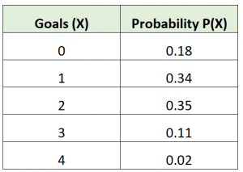

Expected Value = `0*0.18 + 1*0.34 + 2*0.35 + 3*0.11 + 4*0.02 = 1.45 goals.`

Goals Scored: 1, 1, 0, 2, 2, 1, 0, 3, 1, 1, 1, 2, 4, 3, 1

Mean = (1+1+0+2+2+1+0+3+1+1+1+2+4+3+1) / 15 = 1.533 goals.

## Roulette example

[figure not shown]

A roulette wheel in the U.S. contains **38 equally sized spaces**. The wheel is spun and a ball randomly lands in one of these spaces. **Two spaces are green and have numbers 0 and 00 on them**. The other spaces are numbered from **1 to 36**. **Half** of these remaining spaces are **red** and **half** of them are **black**. Different wagers can be made on where the ball will end up landing. A common bet is to choose a **color**, such as red, and wager that the ball will land on any of the 18 red spaces.

#### Probabilities for Roulette

Since the spaces are the same size, the ball is equally likely to land in any of the spaces. This means that a roulette wheel involves a uniform probability distribution. The probabilities that we will need to calculate our expected value are as follows:

- There are a total of 38 spaces, and so the probability that a ball lands on one particular space is 1/38.
- There are 18 red spaces, and so the probability that red occurs is 18/38.
- There are 20 spaces that are black or green, and so the probability that red does not occur is 20/38.

#### Random Variable

The net winnings on a roulette wager can be thought of as a discrete random variable. If we bet `$1` on red and red occurs, then we win our dollar back and another dollar. This results in net winnings of 1. If we bet `$1` on red and green or black occurs, then we lose the dollar that we bet. This results in net winnings of -1.

The random variable X defined as the net winnings from betting on red in roulette will take the value of 1 with probability 18/38 and will take the value -1 with probability 20/38.

#### Calculation of Expected Value

We use the above information with the formula for expected value. Since we have a discrete random variable X for net winnings, the expected value of betting $1 on red in roulette is:

P(Red) x (Value of X for Red) + P(Not Red) x (Value of X for Not Red) = 18/38 x 1 + 20/38 x (-1) = -0.053.

#### Interpretation of Results

**The expected value is very much a measurement of the center or average. It indicates what will happen in the long run every time that we bet $1 on red.**

While we might win several times in a row in the short term, in the long run we will lose over 5 cents on average each time that we play. The presence of the 0 and 00 spaces are just enough to give the house a slight advantage. This advantage is so small that it can be difficult to detect, but in the end, **the house always wins.**

# Discrete Probability Distributions

### 1. Bernoulli Distribution

The Bernoulli distribution is a discrete distribution having two possible outcomes labelled by n=0 and n=1 in which n=1 ("success") occurs with probability p and n=0 ("failure") occurs with probability q=1-p, where 0<p<1.

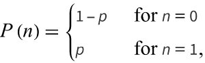

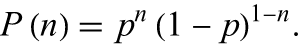

**Example 1**: A basketball player can shoot a ball into the basket with a probability of 0.6. What is the probability that he misses the shot?

**Solution:** We know that success probability P (X = 1) = p = 0.6 Thus, probability of failure is P (X = 0) = 1 - p = 1 - 0.6 = 0.4

P(X = 1) = 0.6

P(X = 0) - prob of missing = (0.6)^0 *(1-0.6)^(1-0) = 1*(0.4) = 0.4

### 2. Binomial Distribution

A binomial experiment is an experiment that has the following properties:

- The experiment consists of $ n $ repeated trials.
- Each trial has only two possible outcomes.
- The probability of success, denoted p, is the same for each trial.
- Each trial is independent.

If a random variable X follows a binomial distribution, then the probability that X = k successes can be found by the following formula:

### $$ P(X = k) = \binom{n}{k}\ast p^{k} \ast (1-p)^{n-k} $$

where:

- n: number of trials
- k: number of successes
- p: probability of success on a given trial
- nCk: the number of ways to obtain k successes in n trials

##### Question: Probaility of getting 3 heads after flipping a coin 4 times

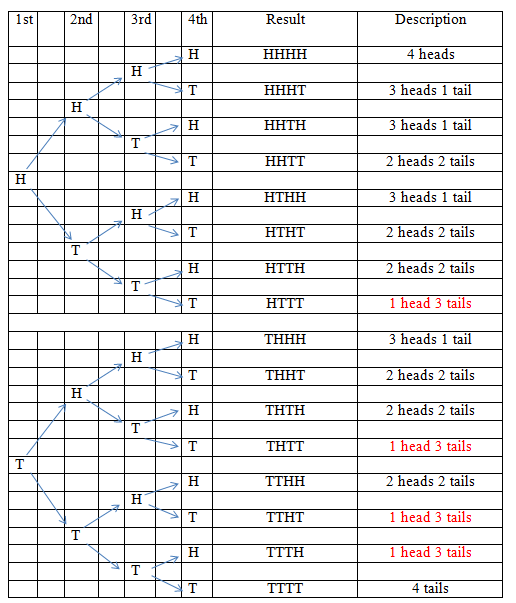

BY applying Binomial equation we need to find:

- P(X = 0) -> What is the Probability of getting zero Heads whenyou toss a coin 4 times?
- P(X = 1)
- ...
- P(X = 4)

```python
from math import comb, factorial
import pandas as pd
```

```python
factorial(4)
```

```
24
```

```python
comb(4,3)
```

```
4
```

```python
# P(X = 0) -> getting 0 HEADS

n = 4
k = 0
P_H = 0.5
P_T = 0.5

comb(n,k) * (P_H)**k * (1-P_H)**(n-k)
```

```
0.0625
```

```python
# P(X = 3) -> getting 3 HEADS
n = 4
k = 3
P_H = 0.5
P_T = 0.5

comb(n,k) * (P_H)**k * (1-P_H)**(n-k)
```

```
0.25
```

#### Write a fucntion to calculcate the probabilities using Binomial equation

```python
def binomial_calc(k,P,n):
    return comb(n,k) * (P)**k * (1-P)**(n-k)
```

```python
binomial_calc(n,P_H, k) # P(X = 0) -> getting 0 HEADS
```

[output not shown]

```python
# Calculate for X = 0,1,2,3,4
```

```python
X = pd.Series([0,1,2,3,4])
```

```python
X
```

```
0    0
1    1
2    2
3    3
4    4
dtype: int64
```

```python
X.apply(binomial_calc, P = 0.5, n = 4)
```

```
0    0.0625
1    0.2500
2    0.3750
3    0.2500
4    0.0625
dtype: float64
```

```python
def binomial_calc(k):
    P, n = 0.5,4
    return comb(n,k) * (P)**k * (1-P)**(n-k)

proba = X.apply(binomial_calc)
```

### Probability Mass Function (PMF) - Discrete Random Variable

PMF is a function over the sample space of a discrete random variable $X$ which gives the probability that $X$ is equal to certain value.

PMF $f(X) = \mathrm{P}[X=x]$

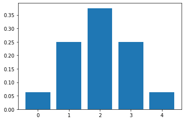

```python
plt.bar(X, proba);
```

## Cumulative Distribution Function (CDF) - Discrete RV

CDF of a random variable $X$ is defined as -

$$ f(X) = P(X \leq x) $$

```python
proba
```

```
0    0.0625
1    0.2500
2    0.3750
3    0.2500
4    0.0625
dtype: float64
```

```python
np.cumsum(proba)
```

```
0    0.0625
1    0.3125
2    0.6875
3    0.9375
4    1.0000
dtype: float64
```

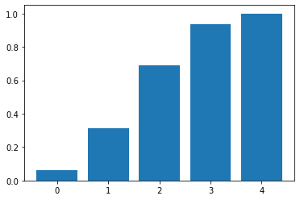

```python
plt.bar(X, np.cumsum(proba));
```

#### Binomial Distribution Problems

**Problem**: A player wins 60% of the matches played. If he plays 12 matches, what is the probability of winning exactly 10?

**Solution**: Using the Binomial Distribution - p = 0.6, n = 12, and k = 10, we find that P(X=10) = 0.06385.

```python
def binomial_calc(k,P,n):
    return comb(n,k) * (P)**k * (1-P)**(n-k)
```

```python
binomial_calc(10,0.6,12)
```

```
0.06385228185599999
```

**Problem**: The probability that a given student gets accepted to a certain college is 0.2. If 10 students apply, what is the probability that more than 4 get accepted?

**Solution**: Using the Binomial Distribution Calculator above with

p = 0.2, n = 10, and k = 4,

we find that P(X>4) = P(X=5) + P(X=6) + ...+P(X=10) = 1-P(X<=4)

```python
X = np.arange(5,11)
```

```python
# suppress the scientific notation in Pandas
pd.set_option('display.float_format', '{:.5f}'.format)
```

```python
pd.Series(X).apply(binomial_calc, P = 0.2, n = 10)
```

```
0   0.02642
1   0.00551
2   0.00079
3   0.00007
4   0.00000
5   0.00000
dtype: float64
```

```python
pd.Series(X).apply(binomial_calc, P = 0.2, n = 10).sum()
```

```
0.03279349760000002
```

### Poisson Distribution

A Poisson experiment is an experiment that has the following properties:

- The number of successes in the experiment can be counted.
- The mean number of successes that occurs during a specific interval of time (or space) is known.
- Each outcome is independent.
- The probability that a success will occur is proportional to the size of the interval.

If a random variable X follows a Poisson distribution, then the probability that $X = k$ successes can be found by the following formula:

## $P(X=k) = λ^k * \frac{e^{–λ}}{k!}$

where:

- λ: mean number of successes that occur during a specific interval
- k: number of successes
- e: a constant equal to approximately 2.71828

For example, suppose a particular hospital experiences an average of 2 births per hour.

- What is the probability that more than 12 births occur in a given hour?
- What is the probability that less than 5 births occur in a given hour?
- What is the probability that between 8 to 11 births occur in a given hour?

### $ P(X=0) = 2^0 * \frac{e^{–2}}{0!} = 0.1353 $

### $ P(X=1) = 2^1 * \frac{e^{–2}}{1!} = 0.2707 $

### $ P(X=2) = 2^2 * \frac{e^{–2}}{2!} = 0.2707 $

### $ P(X=3) = 2^3 * \frac{e^{–2}}{3!} = 0.1805 $

```python
def poisson_cal(k,y):
    return (y**k)*(np.exp(-y)/factorial(k))
```

```python
poisson_cal(0,2) # P(X =0)
```

```
0.1353352832366127
```

```python
# P(X>12) = 1 - P(X<=12)

X = pd.Series(np.arange(13))

1-X.apply(poisson_cal, y=2)

np.round(1-X.apply(poisson_cal, y=2).sum())
```

```
0    0.86466
1    0.72933
2    0.72933
3    0.81955
4    0.90978
5    0.96391
6    0.98797
7    0.99656
8    0.99914
9    0.99981
10   0.99996
11   0.99999
12   1.00000
dtype: float64
```

```
0.0
```

```python
# P(X<5)

X = pd.Series(np.arange(5))

X.apply(poisson_cal, y=2)

X.apply(poisson_cal, y=2).sum()
```

```
0   0.13534
1   0.27067
2   0.27067
3   0.18045
4   0.09022
dtype: float64
```

```
0.9473469826562889
```

```python
# P(8<=X<=11)

X = pd.Series(np.arange(8,12))

X.apply(poisson_cal, y=2)

X.apply(poisson_cal, y=2).sum()
```

```
0   0.00086
1   0.00019
2   0.00004
3   0.00001
dtype: float64
```

```
0.0010953543526990876
```

**Question:** A real estate agent sells on an average 5 houses per month. What is the probabiity of selling more than 7 houses, in a given month?

```python
# P(X>7) = 1-P(X<=7)

X = pd.Series(np.arange(8))

X.apply(poisson_cal, y=5)

1-X.apply(poisson_cal, y=5).sum()
```

```
0   0.00674
1   0.03369
2   0.08422
3   0.14037
4   0.17547
5   0.17547
6   0.14622
7   0.10444
dtype: float64
```

```
0.13337167407000727
```

### Probability Mass Function (PMF)

PMF $f(X) = \mathrm{P}[X=x]$

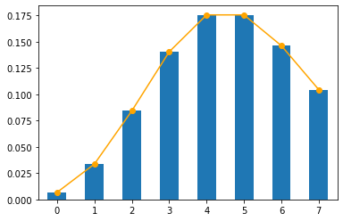

```python
# probability of selling <= 7 houses

X = pd.Series(np.arange(8))
X.apply(poisson_cal, y=5).plot(kind = 'bar')
X.apply(poisson_cal, y=5).plot(kind = 'line', color = 'orange', marker = 'o');
```

## Cumulative Distribution Function (CDF)

CDF of a random variable $X$ is defined as -

$$ f(X) = P(X \leq x) $$

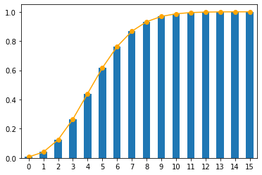

```python
# probability of selling <= 15 houses P(X<=15)

X = pd.Series(np.arange(16))
np.cumsum(X.apply(poisson_cal, y=5)).plot(kind = 'bar')
np.cumsum(X.apply(poisson_cal, y=5)).plot(kind = 'line', color = 'orange', marker = 'o');
```

## Continuous Probability Distributions

- Uniform
- Normal

### Uniform Distribution

If a random variable X follows the uniform distribution, then the probability of X takes a value between x1 and x2 can be found as -

This is the **probability density function** -

## $ P(x_1< X < x_2) = \frac{(x_2-x_1)}{(b-a)}$

- x1 - lower value of interest
- x2 - upper value of interest
- a - min possible value
- b - max possible value

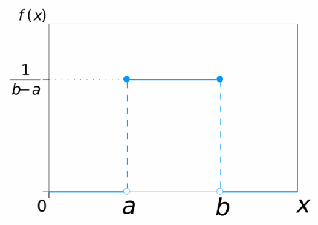

For example, weight of the diamonds uniformly distributed between 1 carat to 1.5 carats. Probability of a randomly found diamond's weight between 1.2 carat to 1.3 carats is -

```python
a,b = 1, 1.5
x1,x2 = 1.2, 1.3
```

```python
# P(x1 < X < x2) = P(1.2<X<1.3)

P_X = (x2-x1)/(b-a)
```

```python
print(P_X)
```

```
0.20000000000000018
```

**Problem:** A train shows up at a metro station every 20 minutes. If you arrive at the metro, what is the probability that the train will show up in 8 minutes or less?

```python
x1,x2 = 0, 8
a,b = 0, 20
```

```python
P_X = (x2-x1)/(b-a)
print(P_X)
```

```
0.4
```

## Normal Distribution

#### Properties of Normal Distribution -

- It is a bell-shaped curve.
- It is symmetrical about the mean, $\mu$. mean = median = mode.
- The total area under the curve is 1 (i.e, 100%).
- 50% of the area to left of the mean & 50% to the right of the mean.

##### Emperical rule (68-95-99 rule)

- Approx. 68% of the data lies within $\mu\pm1\sigma$.
- Approx. 95% of the data lies within $\mu\pm2\sigma$.
- Approx. 99% of the data lies within $\mu\pm3\sigma$.

$X$ is normally distributed with mean $\mu$ and standard deviation $\sigma$: $$X \sim \mathcal{N}(\mu,\,\sigma^{2})$$

## $ \displaystyle pdf(x,\mu,\sigma) = \frac{1}{ \sigma \sqrt{2 \pi}} e^{\left(-\frac{{\left(\mu - x\right)}^{2}}{2 \, \sigma^{2}}\right)} $

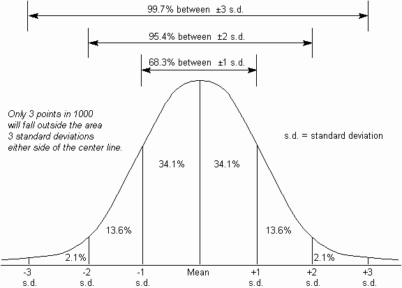

#### Std. Norm Dist $ N(0,1) $ using Numpy `randn`

```
-0.0
```

```
0.0
```

```
1.0
```

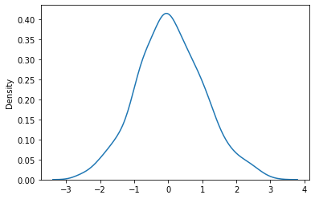

```python
np.random.seed(123)
np.random.randn(1000).mean().round()
np.median(np.random.randn(1000)).round()
np.random.randn(1000).std().round()

sns.kdeplot(np.random.randn(1000))
```

### Central Limit Theorem (CLT)

```python
np.random.seed(123)
# salaries (in lakhs) of a junior to mid level IT job
np.round(np.random.uniform(3.6,9.1, size=30),2)

salary = np.round(np.random.uniform(3.6,9.1, size=3000),2)
```

```
array([7.43, 5.17, 4.85, 6.63, 7.56, 5.93, 8.99, 7.37, 6.25, 5.76, 5.49,
       7.61, 6.01, 3.93, 5.79, 7.66, 4.6 , 4.56, 6.52, 6.53, 7.09, 8.27,
       7.58, 6.96, 7.57, 5.38, 5.59, 4.86, 5.22, 7.07])
```

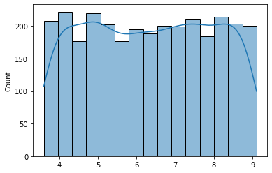

```python
sns.histplot(salary, kde = True);
```

```python
# Mean and Std Dev
np.mean(salary)
np.std(salary)
```

```
6.340756666666666
```

```
1.6055478382125177
```

```python
# Mean ± 1SD

np.mean(salary)+np.std(salary)

np.mean(salary)- np.std(salary)
```

```
7.946304504879183
```

```
4.735208828454148
```

```python
pd.Series(salary).between(4.73, 7.94).value_counts()
```

```
True     1740
False    1260
dtype: int64
```

```python
1740/3000 # 58% of the data is lying with in Mean±1sd
```

```
0.58
```

### Apply CLT

```python
np.random.seed(123)
df1 = pd.DataFrame(np.round(np.random.uniform(3.6,9.1, size=(3000,300)),2))
```

```python
df1.shape
```

```
(3000, 300)
```

```python
df1.head()
```

|  | 0 | 1 | 2 | 3 | 4 | 5 | 6 | 7 | 8 | 9 | ... | 290 | 291 | 292 | 293 | 294 | 295 | 296 | 297 | 298 | 299 |
| --- | --- | --- | --- | --- | --- | --- | --- | --- | --- | --- | --- | --- | --- | --- | --- | --- | --- | --- | --- | --- | --- |
| 0 | 7.43 | 5.17 | 4.85 | 6.63 | 7.56 | 5.93 | 8.99 | 7.37 | 6.25 | 5.76 | ... | 5.96 | 8.40 | 5.56 | 8.71 | 4.42 | 8.77 | 8.18 | 8.25 | 4.28 | 6.88 |
| 1 | 3.69 | 7.57 | 3.64 | 4.07 | 4.84 | 8.41 | 5.60 | 6.57 | 6.72 | 4.84 | ... | 6.16 | 5.99 | 5.82 | 4.27 | 6.49 | 6.05 | 7.25 | 6.62 | 3.75 | 3.78 |
| 2 | 7.46 | 7.49 | 8.88 | 8.42 | 6.17 | 7.04 | 6.11 | 4.83 | 5.67 | 4.17 | ... | 7.24 | 6.67 | 5.53 | 4.67 | 4.61 | 4.05 | 4.05 | 8.25 | 5.71 | 3.93 |
| 3 | 8.53 | 4.83 | 5.07 | 4.67 | 8.92 | 4.22 | 7.57 | 8.73 | 7.27 | 8.32 | ... | 7.51 | 7.61 | 3.74 | 8.89 | 4.36 | 7.55 | 5.69 | 8.38 | 9.07 | 4.66 |
| 4 | 8.11 | 6.38 | 8.91 | 7.22 | 6.86 | 4.86 | 7.55 | 5.19 | 8.25 | 8.97 | ... | 7.08 | 3.77 | 4.32 | 5.71 | 7.25 | 7.12 | 4.66 | 4.33 | 8.76 | 5.55 |

5 rows × 300 columns

```python
df1['SampleMean'] = df1.mean(axis=1)
```

```python
df1.head()
```

|  | 0 | 1 | 2 | 3 | 4 | 5 | 6 | 7 | 8 | 9 | ... | 291 | 292 | 293 | 294 | 295 | 296 | 297 | 298 | 299 | SampleMean |
| --- | --- | --- | --- | --- | --- | --- | --- | --- | --- | --- | --- | --- | --- | --- | --- | --- | --- | --- | --- | --- | --- |
| 0 | 7.43 | 5.17 | 4.85 | 6.63 | 7.56 | 5.93 | 8.99 | 7.37 | 6.25 | 5.76 | ... | 8.40 | 5.56 | 8.71 | 4.42 | 8.77 | 8.18 | 8.25 | 4.28 | 6.88 | 6.341267 |
| 1 | 3.69 | 7.57 | 3.64 | 4.07 | 4.84 | 8.41 | 5.60 | 6.57 | 6.72 | 4.84 | ... | 5.99 | 5.82 | 4.27 | 6.49 | 6.05 | 7.25 | 6.62 | 3.75 | 3.78 | 6.325967 |
| 2 | 7.46 | 7.49 | 8.88 | 8.42 | 6.17 | 7.04 | 6.11 | 4.83 | 5.67 | 4.17 | ... | 6.67 | 5.53 | 4.67 | 4.61 | 4.05 | 4.05 | 8.25 | 5.71 | 3.93 | 6.471933 |
| 3 | 8.53 | 4.83 | 5.07 | 4.67 | 8.92 | 4.22 | 7.57 | 8.73 | 7.27 | 8.32 | ... | 7.61 | 3.74 | 8.89 | 4.36 | 7.55 | 5.69 | 8.38 | 9.07 | 4.66 | 6.052467 |
| 4 | 8.11 | 6.38 | 8.91 | 7.22 | 6.86 | 4.86 | 7.55 | 5.19 | 8.25 | 8.97 | ... | 3.77 | 4.32 | 5.71 | 7.25 | 7.12 | 4.66 | 4.33 | 8.76 | 5.55 | 6.475967 |

5 rows × 301 columns

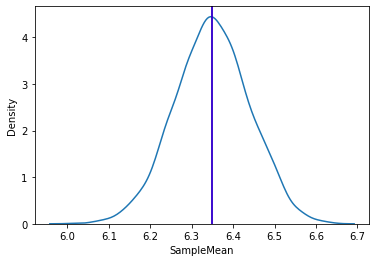

```python
sns.kdeplot(df1.SampleMean)
plt.axvline(df1.SampleMean.mean(), color = 'red')
plt.axvline(df1.SampleMean.median(), color = 'blue');
```

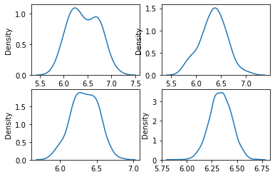

```python
# Effect of sample size
np.random.seed(123)
plt.subplot(221)
sns.kdeplot([pd.Series(salary).sample(20).mean() for i in range(40)])
plt.subplot(222)
sns.kdeplot([pd.Series(salary).sample(40).mean() for i in range(80)])
plt.subplot(223)
sns.kdeplot([pd.Series(salary).sample(80).mean() for i in range(200)])
plt.subplot(224)
sns.kdeplot([pd.Series(salary).sample(200).mean() for i in range(3000)]);
```

```python
df1.SampleMean.mean()
df1.SampleMean.std()
```

```
6.349233644444444
```

```
0.09038176709192468
```

```python
mean_p_1sd = df1.SampleMean.mean()+df1.SampleMean.std()
mean_m_1sd = df1.SampleMean.mean()-df1.SampleMean.std()
```

```python
print(mean_p_1sd, mean_m_1sd)
```

```
6.439615411536369 6.2588518773525195
```

```python
df1.SampleMean.between(mean_m_1sd,mean_p_1sd).value_counts()
```

```
True     2031
False     969
Name: SampleMean, dtype: int64
```

```python
2031/3000
```

```
0.677
```

```python
mean_p_2sd = df1.SampleMean.mean()+ 2* df1.SampleMean.std()
mean_m_2sd = df1.SampleMean.mean()- 2* df1.SampleMean.std()
```

```python
df1.SampleMean.between(mean_m_2sd,mean_p_2sd).value_counts()
```

```
True     2867
False     133
Name: SampleMean, dtype: int64
```

```python
2867/3000
```

```
0.9556666666666667
```

```python
mean_p_3sd = df1.SampleMean.mean()+ 3* df1.SampleMean.std()
mean_m_3sd = df1.SampleMean.mean()- 3* df1.SampleMean.std()
```

```python
df1.SampleMean.between(mean_m_3sd,mean_p_3sd).value_counts()
```

```
True     2993
False       7
Name: SampleMean, dtype: int64
```

```python
2993/3000
```

```
0.9976666666666667
```

```python
(df1.SampleMean < 6.34).value_counts()
```

```
False    1620
True     1380
Name: SampleMean, dtype: int64
```

```python
1620/3000
```

```
0.54
```

### Z-Score

- A z-score measures the distance between a data point and the mean using standard deviations.
- Z-scores can be positive or negative.
- The sign tells you whether the observation is above or below the mean.
- For example, a z-score of +2 indicates that the data point falls two standard deviations above the mean, while a -2 signifies it is two standard deviations below the mean.
- A z-score of zero equals the mean.
- z-score is also referred as standard score.

Standardizing the raw data by transforming them into z-scores provides the following benefits:

- Understand where a data point fits into a distribution.
- Compare observations between dissimilar variables.
- Identify outliers
- Calculate probabilities and percentiles using the standard normal distribution.

Z-score is the number of standard deviations from the mean a data point is.

### $$ Z = \frac{x-\mu}{\sigma}$$

n% of data points lie with in $\mu±z*\sigma$

```python
m = df1.SampleMean.mean() # from the above data frame SampleMean column
sd = df1.SampleMean.std()
```

```python
# 6.25 lies within ______ Std Dev away from the Mean.
# find the Z-score of 6.25

z = (6.25-m)/sd
print(z)
```

```
-1.0979387506720986
```

```python
# 7.88 lies within ______ Std Dev away from the Mean.
# find the Z-score of 7.88

z = (7.88-m)/sd
print(z)
```

```
16.93667212767214
```

### Normal Probabilities Practice Problems

**Q1**. Most graduate schools of business require applicants for admission to take the Graduate Management Admission Council’s GMAT examination. Scores on the GMAT are roughly normally distributed with a mean of 527 and a standard deviation of 112. What is the probability of an individual scoring above 500 on the GMAT?

Ref. to the Normal Probabilities Practice Problems PDF file.

## Confidence Interval (CI)

Statistics is interested in measuring population parameters – numbers that describe some characteristic of an entire population.

Two of the most common population parameters are:

1. Population mean: the mean value of some variable in a population (e.g. the mean height of males in the U.S.)
2. Population proportion: the proportion of some variable in a population (e.g. the proportion of residents in a county who support a certain law)

Confidence Interval = [lower bound, upper bound]

Confidence Interval = $ sample\ statistic \pm margin\ of\ error $

### Standard Error

In statistics, the standard error is the standard deviation of the sample distribution. The sample mean of a data is generally varied from the actual population mean. It is represented as SE. It is used to measure the amount of accuracy by which the given sample represents its population.

**The standard error of a statistic or an estimate of a parameter is the standard deviation of its sampling distribution.**

## $ SE = \dfrac{s}{\sqrt{n}} $

- SE = standard error of the sample
- $ s $ = sample standard deviation
- n = number of samples

### Confidence Interval (CI) = $ \bar{x}\pm z * \dfrac{s}{\sqrt{n}} $

- CI = confidence interval
- $\bar{x}$ = sample mean
- z = confidence level value
- ${s}$ = sample standard deviation
- ${n}$ = sample size

### Pizza weights example

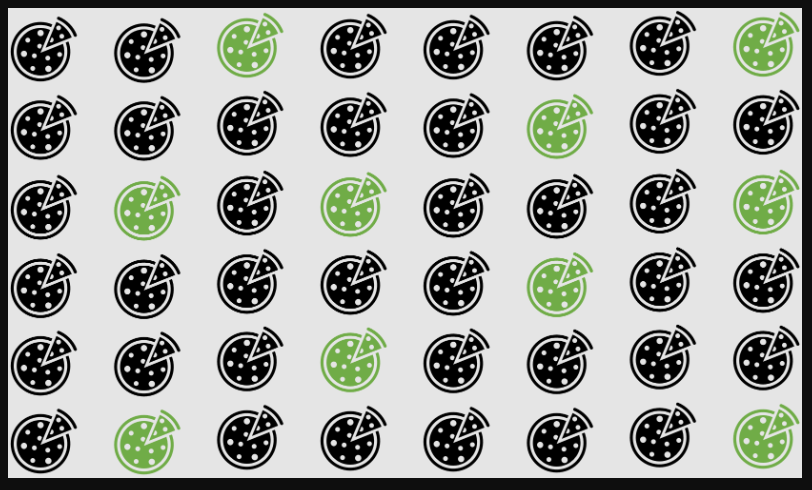

```python
# sample mean - xbar

xbar = np.mean([170,180,185,175,171])
print(xbar)
```

```
176.2
```

```python
sd = 6.3
n = 5
# z = ?
```

#### Find The Z Score for a given Confidence Level of a Normal Distribution

Area under the curve left $ A_L = \dfrac{1 + CI}{2} = \dfrac{1 + 0.95}{2} = \dfrac{1.95}{2} = 0.975 $

```python
#for 0.975, the Z scre is....

z = 1.9 + 0.06
print(z)
```

```
1.96
```

| CI | alpha (α) | Z-Score |
| --- | --- | --- |
| 90% | 0.1 | 1.645 |
| 95% | 0.05 | 1.96 |
| 98% | 0.02 | 2.33 |
| 99% | 0.01 | 2.575 |

https://www.ztable.net/

$ CI = \bar{x}\pm z * \dfrac{s}{\sqrt{n}} = 176.2 \pm 1.96 * \dfrac{6.3}{\sqrt{5}} = 176.2 \pm 5.53 = [170.67, 181.73] $

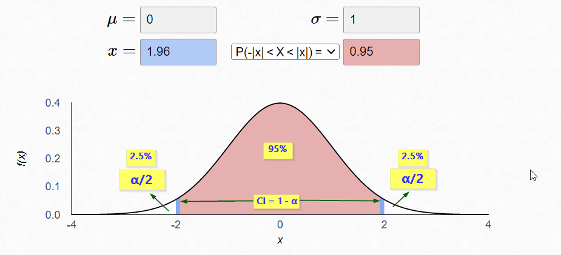

### Refer to the z table to find the z score

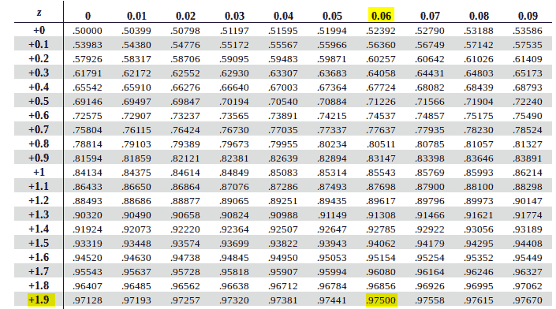

### Hypothesis Testing

- A statistical hypothesis is an assumption about a **population parameter.**
- The assumption about the weight is the **statistical hypothesis** and the true mean weight of a Pizza is the **population parameter.**
- A **hypothesis test** is a formal statistical test we use to reject or fail to reject a statistical hypothesis.

#### Two Types of Statistical Hypotheses

To test whether a statistical hypothesis about a population parameter is true, we obtain a **random sample** from the population and perform a hypothesis test on the sample data.

There are two types of statistical hypotheses:

1. **Null hypothesis** - denoted as $H_0$.
   - The null hypothesis is the claim that there’s no effect in the population.
   - In simple terms - A null hypothesis is a statement, in which there is no relationship between two variables.No change/effect is observed.
   - Null hypotheses often include phrases such as “no effect,” “no difference,” or “no relationship.”
2. **Alternative hypothesis** - denoted as $H_1$ or $H_a$.
   - Alternative hypothesis is the same as your research hypothesis. In other words, it’s the claim that you expect or hope will be true.
   - The alternative hypothesis is the opposite to the null hypothesis.
   - Some change/effect is observed.

#### Hypothesis testing summary

|  | **Null hypotheses ($H_0$)** | **Alternative hypotheses ($H_0$)** |
| --- | --- | --- |
| Definition | A claim that there is no effect in the population. | A claim that there is an effect in the population. |
| Also known as | H0 | Ha H1 |
| Typical phrases used | - No effect - No difference - No relationship - No change - Does not increase - Does not decrease | - An effect - A difference - A relationship - A change - Increases - Decreases |
| Symbols used | Equality symbol (=, ≥, or ≤) | Inequality symbol (≠, <, or >) |
| p ≤ α | Reject $H_0$ | Accept $H_a$ |
| p > α | Failed to reject $H_0$ | Reject $H_a$ |

#### Examples

| Question | Null Hypothesis ($H_0$) | Alternate Hypothesis ($H_a$) |
| --- | --- | --- |
| Does tooth flossing affect the number of cavities? | Tooth flossing has **no effect** on the number of cavities. | Tooth flossing **has an effect** on the number of cavities. |
| What is the mean salary of a Data Scientist? | The mean data scientist salary is 113,000 dollar. $ \mu = 113000 $ | The mean data scientist salary is not 113,000 dollars. $\mu \neq 113000$ |
| Does low carb diet promote weight loss than a low fat diet? | There is no difference in the mean amount of weight loss when comparing a low carbohydrate diet with a low fat diet. $ \mu_{weight loss on low carb diet} = \mu_{weight loss on low fat diet}$ | The mean amount of weight loss is greater on a low carbohydrate diet compared to a low fat diet. $ \mu_{weight loss on low carb diet} > \mu_{weight loss on low fat diet}$ |

#### Hypothesis Testing process

A hypothesis test consists of **five** steps:

**1. State the hypotheses.**

State the null and alternative hypotheses. These two hypotheses need to be mutually exclusive, so if one is true then the other must be false.

**2. Determine a significance level to use for the hypothesis.**

Decide on a significance level. Common choices are .01, .05, and .1.

**3. Find the test statistic.**

Find the test statistic and the corresponding p-value. Often we are analyzing a population mean or proportion and the general formula to find the test statistic is: (sample statistic – population parameter) / (standard deviation of statistic)

**4. Reject or fail to reject the null hypothesis.**

Using the test statistic or the p-value, determine if you can reject or fail to reject the null hypothesis based on the significance level.

The p-value tells us the strength of evidence in support of a null hypothesis. If the p-value is less than the significance level, we reject the null hypothesis.

**5. Interpret the results.**

Interpret the results of the hypothesis test in the context of the question being asked.

#### Hypothesis testing - Decision Errors

There are two types of decision errors that one can make when doing a hypothesis test:

1. **Type I error:** You reject the null hypothesis when it is actually true. The probability of committing a Type I error is equal to the significance level, often called **alpha**, and denoted as **α**.
2. **Type II error:** You fail to reject the null hypothesis when it is actually false. The probability of committing a Type II error is called the Power of the test or **Beta**, denoted as **β**.

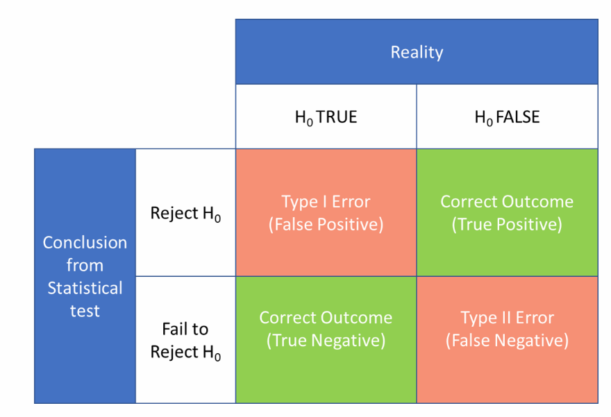

#### Directional Hypothesis : One-Tailed and Two-Tailed Tests

A hypothesis test can either contain a directional hypothesis or a non-directional hypothesis:

- **Directional hypothesis:** The alternative hypothesis contains the less than **(“<“)** or greater than **(“>”)** sign. This indicates that we’re testing whether or not there is a positive or negative effect.
- **Non-directional hypothesis:** The alternative hypothesis contains the not equal **(“≠”)** sign. This indicates that we’re testing whether or not there is some effect, without specifying the direction of the effect.

Note that directional hypothesis tests are also called **“one-tailed”** tests and non-directional hypothesis tests are also called **“two-tailed”** tests.

**Example 1: Competitive exam coaching**

A trianing institute believes a certain 4-week program will increase the mean percentage of their students, which is currently 0.66.

To test this, he measures the mean percentage of each of students before and after participating in the program.

He then performs a hypothesis test using the following hypotheses:

- $H_0$: μ = 0.66 (the program will have no effect on the mean percentage)
- $H_A$: μ > 0.66 (the program will cause mean percentage to increase)

This is an example of a directional hypothesis because the alternative hypothesis contains the greater than “>” sign. The institute believes that the program will influence themean percentage of their students in a positive direction.

**Example 2: Smoking effect on life time**

A researcher believes that Smoking reduces the life time of a person, which is currently 80 years.

He performs a hypothesis test using the following hypotheses:

- $H_0$: μ = 80 years (smoking has no effect on life time)
- $H_A$: μ < 80 years (smoking decreases the life time)

This is also an example of a directional hypothesis because the alternative hypothesis contains the less than “<” sign - in a negative direction.

**Example 3: Non-directional Hypothesis**

What is the mean salary of a Data Scientist?

- $H_0$: The mean data scientist salary is 113,000 dollar (𝜇=113000)
- $H_A$: The mean data scientist salary is not 113,000 dollars (𝜇≠113000)

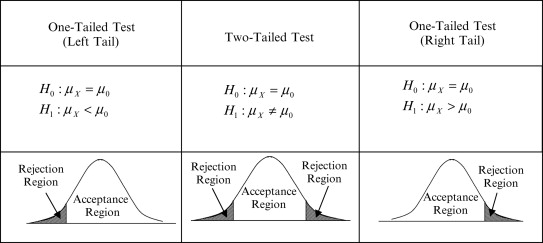

### P-value

- In Statistics, the observed result, which is known as **test static** need to be statistically significant.
- P-value determines the statistical significance.
- The P-value is known as the probability value.
- P-values are used in hypothesis testing to help decide whether to reject the null hypothesis.
- A p-value less than 0.05 (typically ≤ 0.05) is statistically significant. It indicates strong evidence against the null hypothesis, as there is less than a 5% probability the null hypotheses is correct (and the results are random). Therefore, we reject the null hypothesis, and accept the alternative hypothesis.
- A p-value higher than 0.05 (> 0.05) is not statistically significant and indicates strong evidence for the null hypothesis. This means we retain the null hypothesis and reject the alternative hypothesis.

### Significance level

- The **significance level, or alpha (α)**, is a value that the researcher sets in advance as the threshold for statistical significance.
- It is the maximum risk of making a false positive conclusion (Type I error) that you are willing to accept.
- If the p value is **higher** than the significance level **(p > α)**, the null hypothesis is not rejected, and the results are not **statistically significant**.
- If the p value is **lower** than the significance level **(p < α)**, the results are interpreted as rejecting the null hypothesis and reported as statistically significant.
- Usually, the significance level is set to 0.05 or 5%. That means your results must have a 5% or lower chance of occurring under the null hypothesis to be considered statistically significant.

# Statistical Tests

## t-test

A t-test is a statistical test that is used to compare the means of two groups.

| Test | Purpose | Example |
| --- | --- | --- |
| 1-Sample t | Tests whether the mean of a single population is equal to a target value | Is the mean salary of a graduate from a college is greater than $120k? |
| 2-Sample t | Tests whether the difference between the means of two independent populations is equal to a target value | Does the mean salary of female college graduate significantly differ from the mean salary of male college graduate? |

# t.ly/nPeo

## One Sample t-test

**Question**: ABC Marketing agency reported that the typical college student spends a mean of 144 minutes (2.4 hours) per day accessing the social networking sites via a mobile device. In order to test the validity of this statement, you select a sample of 30 friends. The results for the time spent per day in minutes are stored in a csv file.

Is there evidence that the population mean time spent per day accessing the social networking sites via mobile device is different from 144 minutes? Use the p-value approach and a level of significance of 0.05.

```python
import numpy as np
import pandas as pd
from scipy import stats
```

```python
df = pd.read_csv(r'C:\Data\t_test\SocialMediaTime.csv')
```

```python
df.head()
```

|  | Minutes |
| --- | --- |
| 0 | 72 |
| 1 | 144 |
| 2 | 48 |
| 3 | 72 |
| 4 | 36 |

**1. State the hypotheses.**

##### Null hypothesis states that mean usage time, $\mu$ is equals to 144.

##### Alternative hypothesis states that the mean usage time, $\mu$ is unequal to 144.

- $H_0$: $\mu$ = 144
- $H_A$: $\mu$ $\neq$ 144

**2. Determine a significance level to use for the hypothesis.**

$ \alpha = 0.05$

**3. Find the test statistic.**

```python
# perform one-sample t-test

alpha = 0.05

t_stat, p = stats.ttest_1samp(df['Minutes'], popmean=144)

print(t_stat, p)
```

```
1.2246743653638934 0.23055326882983757
```

**4. Reject or fail to reject the null hypothesis.**

```python
if p<alpha:
    print("Reject Null Hypothesis")
else:
    print("Fail to Reject Null Hypothesis")
```

```
Fail to Reject Null Hypothesis
```

```python
print("Critical value :", stats.t.ppf(q = 0.05, df = 29))
if t_stat>stats.t.ppf(q = 0.05, df = 24):
    print("Reject Null Hypothesis")
else:
    print("Fail to Reject Null Hypothesis")
```

```
Critical value : -1.6991270265334977
Reject Null Hypothesis
```

**5. Interpret the results.**